# 4 Clustering and classification

## Setup

First let’s load the needed packages and some custom functions.

```r
# Packages
pacman::p_load(tidyverse)

# Custom functions
source("src/theme_darkmode.R")
```

## 4.2 Get data

### Instructions

> Load the Boston data from the MASS package. Explore the structure and the dimensions of the data and describe the dataset briefly, assuming the reader has no previous knowledge of it. Details about the Boston dataset can be seen for example here. (0-1 points)

Save the data to an object and check its structure

```r
# Read data
data <- MASS::Boston

# Glance at the data
finalfit::finalfit_glimpse(data)$Continuous %>%
  select(-label) %>%
  knitr::kable()
```

|  | var_type | n | missing_n | missing_percent | mean | sd | min | quartile_25 | median | quartile_75 | max |
| --- | --- | --- | --- | --- | --- | --- | --- | --- | --- | --- | --- |
| crim |  | 506 | 0 | 0.0 | 3.6 | 8.6 | 0.0 | 0.1 | 0.3 | 3.7 | 89.0 |
| zn |  | 506 | 0 | 0.0 | 11.4 | 23.3 | 0.0 | 0.0 | 0.0 | 12.5 | 100.0 |
| indus |  | 506 | 0 | 0.0 | 11.1 | 6.9 | 0.5 | 5.2 | 9.7 | 18.1 | 27.7 |
| chas |  | 506 | 0 | 0.0 | 0.1 | 0.3 | 0.0 | 0.0 | 0.0 | 0.0 | 1.0 |
| nox |  | 506 | 0 | 0.0 | 0.6 | 0.1 | 0.4 | 0.4 | 0.5 | 0.6 | 0.9 |
| rm |  | 506 | 0 | 0.0 | 6.3 | 0.7 | 3.6 | 5.9 | 6.2 | 6.6 | 8.8 |
| age |  | 506 | 0 | 0.0 | 68.6 | 28.1 | 2.9 | 45.0 | 77.5 | 94.1 | 100.0 |
| dis |  | 506 | 0 | 0.0 | 3.8 | 2.1 | 1.1 | 2.1 | 3.2 | 5.2 | 12.1 |
| rad |  | 506 | 0 | 0.0 | 9.5 | 8.7 | 1.0 | 4.0 | 5.0 | 24.0 | 24.0 |
| tax |  | 506 | 0 | 0.0 | 408.2 | 168.5 | 187.0 | 279.0 | 330.0 | 666.0 | 711.0 |
| ptratio |  | 506 | 0 | 0.0 | 18.5 | 2.2 | 12.6 | 17.4 | 19.1 | 20.2 | 22.0 |
| black |  | 506 | 0 | 0.0 | 356.7 | 91.3 | 0.3 | 375.4 | 391.4 | 396.2 | 396.9 |
| lstat |  | 506 | 0 | 0.0 | 12.7 | 7.1 | 1.7 | 6.9 | 11.4 | 17.0 | 38.0 |
| medv |  | 506 | 0 | 0.0 | 22.5 | 9.2 | 5.0 | 17.0 | 21.2 | 25.0 | 50.0 |

**Source**

- Harrison, D. and Rubinfeld, D.L. (1978) Hedonic prices and the demand for clean air. *J. Environ. Economics and Management* 5, 81–102.
- Belsley D.A., Kuh, E. and Welsch, R.E. (1980) *Regression Diagnostics. Identifying Influential Data and Sources of Collinearity.* New York: Wiley.

## 4.3 Visualize

### Instructions

> Show a graphical overview of the data and show summaries of the variables in the data. Describe and interpret the outputs, commenting on the distributions of the variables and the relationships between them. (0-2 points)

Let’s start by exploring our data.

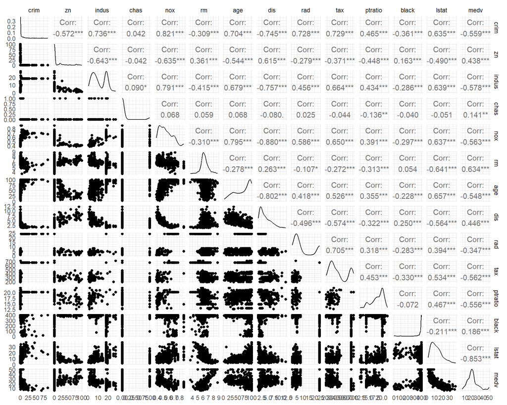

```r
# "chas" to nominal
# data <- data %>%
#   mutate(
#     chas = case_when(
#       chas == 1 ~ "Bounds river",
#       T ~ "Does not bound river"
#     )
#   )

# Plot
data %>%
  GGally::ggpairs(
    lower = list(continuous = "points", size = .01),
    upper = list(continuous = GGally::wrap("cor", method = "spearman")),
  ) + theme_minimal()
```

## 4.4 Standardize

### Instructions

> Standardize the dataset and print out summaries of the scaled data. How did the variables change? Create a categorical variable of the crime rate in the Boston dataset (from the scaled crime rate). Use the quantiles as the break points in the categorical variable. Drop the old crime rate variable from the dataset. Divide the dataset to train and test sets, so that 80% of the data belongs to the train set. (0-2 points)

Let’s scale the data so that every variable has a mean $\overline{x} = 0$ and sd $σ = 1$.

```r
# Standardize
data_z <- scale(data) %>% data.frame()

# Summaries
finalfit::finalfit_glimpse(data_z)$Continuous %>% gt::gt()
```

| label | var_type | n | missing_n | missing_percent | mean | sd | min | quartile_25 | median | quartile_75 | max |
| --- | --- | --- | --- | --- | --- | --- | --- | --- | --- | --- | --- |
| crim | <dbl> | 506 | 0 | 0.0 | -0.0 | 1.0 | -0.4 | -0.4 | -0.4 | 0.0 | 9.9 |
| zn | <dbl> | 506 | 0 | 0.0 | 0.0 | 1.0 | -0.5 | -0.5 | -0.5 | 0.0 | 3.8 |
| indus | <dbl> | 506 | 0 | 0.0 | 0.0 | 1.0 | -1.6 | -0.9 | -0.2 | 1.0 | 2.4 |
| chas | <dbl> | 506 | 0 | 0.0 | -0.0 | 1.0 | -0.3 | -0.3 | -0.3 | -0.3 | 3.7 |
| nox | <dbl> | 506 | 0 | 0.0 | -0.0 | 1.0 | -1.5 | -0.9 | -0.1 | 0.6 | 2.7 |
| rm | <dbl> | 506 | 0 | 0.0 | -0.0 | 1.0 | -3.9 | -0.6 | -0.1 | 0.5 | 3.6 |
| age | <dbl> | 506 | 0 | 0.0 | -0.0 | 1.0 | -2.3 | -0.8 | 0.3 | 0.9 | 1.1 |
| dis | <dbl> | 506 | 0 | 0.0 | 0.0 | 1.0 | -1.3 | -0.8 | -0.3 | 0.7 | 4.0 |
| rad | <dbl> | 506 | 0 | 0.0 | 0.0 | 1.0 | -1.0 | -0.6 | -0.5 | 1.7 | 1.7 |
| tax | <dbl> | 506 | 0 | 0.0 | 0.0 | 1.0 | -1.3 | -0.8 | -0.5 | 1.5 | 1.8 |
| ptratio | <dbl> | 506 | 0 | 0.0 | -0.0 | 1.0 | -2.7 | -0.5 | 0.3 | 0.8 | 1.6 |
| black | <dbl> | 506 | 0 | 0.0 | -0.0 | 1.0 | -3.9 | 0.2 | 0.4 | 0.4 | 0.4 |
| lstat | <dbl> | 506 | 0 | 0.0 | -0.0 | 1.0 | -1.5 | -0.8 | -0.2 | 0.6 | 3.5 |
| medv | <dbl> | 506 | 0 | 0.0 | -0.0 | 1.0 | -1.9 | -0.6 | -0.1 | 0.3 | 3.0 |

## 4.5 Discriminant analysis

### Instructions

> Fit the linear discriminant analysis on the train set. Use the categorical crime rate as the target variable and all the other variables in the dataset as predictor variables. Draw the LDA (bi)plot. (0-3 points)

## 4.6

### Instructions

> Save the crime categories from the test set and then remove the categorical crime variable from the test dataset. Then predict the classes with the LDA model on the test data. Cross tabulate the results with the crime categories from the test set. Comment on the results. (0-3 points)

## 4.7

### Instructions

> Reload the Boston dataset and standardize the dataset (we did not do this in the Exercise Set, but you should scale the variables to get comparable distances). Calculate the distances between the observations. Run k-means algorithm on the dataset. Investigate what is the optimal number of clusters and run the algorithm again. Visualize the clusters (for example with the pairs() or ggpairs() functions, where the clusters are separated with colors) and interpret the results. (0-4 points)

## Bonus

### Instructions

> Perform k-means on the original Boston data with some reasonable number of clusters (> 2). Remember to standardize the dataset. Then perform LDA using the clusters as target classes. Include all the variables in the Boston data in the LDA model. Visualize the results with a biplot (include arrows representing the relationships of the original variables to the LDA solution). Interpret the results. Which variables are the most influential linear separators for the clusters? (0-2 points to compensate any loss of points from the above exercises)

## Super-Bonus

### Instructions

> Run the code below for the (scaled) train data that you used to fit the LDA. The code creates a matrix product, which is a projection of the data points.

```
model_predictors <- dplyr::select(train, -crime)
# check the dimensions
dim(model_predictors)
dim(lda.fit$scaling)
# matrix multiplication
matrix_product <- as.matrix(model_predictors) %*% lda.fit$scaling
matrix_product <- as.data.frame(matrix_product)
```